# Map of serosurveillance sites

## Packages

The needed packages:

```r
library(sf)
library(magrittr)
library(stringr)
library(purrr)
library(dplyr)
```

## Functions

The following function retrieves the tables from an URL (typically a wikipedia page):

```r
get_table <- function(url) {
  url %>%
    httr::GET() %>%
    httr::content("text") %>%
    XML::readHTMLTable()
}
```

The following function transform a continuous variable into a categorical one:

```r
discretize <- function(x, breaks) {
  x %>%
    cut(breaks, include.lowest = TRUE) %>%
    as.integer()
}
```

The following function adds the provinces of a country to an already existing map:

```r
add_gadm <- function(x) {
  x %>%
    st_geometry() %>%
    plot(add = TRUE, col = x$color, lwd = .1)
}
```

## Data

Downloading the province map for Vietnam and Indonesia:

```r
download.file("https://biogeo.ucdavis.edu/data/gadm3.6/Rsf/gadm36_VNM_1_sf.rds", "gadm36_VNM_1_sf.rds")
download.file("https://biogeo.ucdavis.edu/data/gadm3.6/Rsf/gadm36_IDN_1_sf.rds", "gadm36_IDN_1_sf.rds")
```

Loading these maps:

```r
vnm <- readRDS("gadm36_VNM_1_sf.rds")
idn <- readRDS("gadm36_IDN_1_sf.rds")
```

Retrieving the world map:

```r
worldmap <- st_as_sf(rworldmap::getMap(resolution = "low"))
```

Retrieving province codes for Indonesia from [Statoids](http://www.statoids.com):

```r
statoids <- XML::readHTMLTable("http://www.statoids.com/uid.html")[[2]]
names(statoids) <- trimws(names(statoids))
statoids <- na.exclude(with(statoids, setNames(HASC, ISO)))
```

The unprojected CRS:

```r
proj <- st_crs(vnm)
```

Loading the coordinates of the Vietnamese sites:

```r
vnm_sites <- "hospitals VNM.txt" %>%
  read.table(sep = "\t") %>%
  setNames("a") %>%
  mutate_at("a", ~ trimws(str_remove_all(tolower(.x), "[a-z]|\\(|\\)"))) %>%
  tidyr::separate(a, c("y", "x"), sep = ",") %>%
  mutate_all(as.numeric) %>%
  st_as_sf(coords = c("x", "y"), crs = proj)
```

Loading the coordinates of the Indonesian sites:

```r
idn_sites <- "hospitals IDN.txt" %>%
  read.table(sep = ",") %>%
  st_as_sf(coords = c("V2", "V1"), crs = proj)
```

Downloading the province population density for Vietnam:

```r
vnm_table <- "https://en.wikipedia.org/wiki/Provinces_of_Vietnam#List_and_statistics" %>%
  get_table() %>%
  extract2(5) %>%
  extract(c("V1", "V6")) %>%
  extract(-1, ) %>%
  setNames(c("NAME_1", "density")) %>%
  mutate(NAME_1 = NAME_1 %>%
           str_remove_all(" Province| City") %>%
           stringdist::amatch(vnm$NAME_1, maxDist = 10) %>%
           extract(vnm$NAME_1, .),
         density  = as.numeric(str_remove(density, ",")))
```

Downloading the province population density for Indonesia:

```r
idn_table <- "https://en.wikipedia.org/wiki/Provinces_of_Indonesia#Table_of_provinces" %>%
  get_table() %>%
  extract(3) %>%
  extract2(1) %>%
  extract(c("V4", "V8")) %>%
  extract(-1, ) %>%
  setNames(c("HASC_1", "density")) %>%
  mutate(HASC_1 = HASC_1 %>%
           str_remove_all("\\[|\\]|\\d") %>%
           str_replace(".*-", "") %>%
           extract(statoids, .),
         density  = 1.134 * as.numeric(str_remove(density, ",")))
```

## Map

Merging the province population density with the maps:

```r
idn %<>% left_join(idn_table, "HASC_1")
vnm %<>% left_join(vnm_table, "NAME_1")
```

Retrieving the countries of Southeast Asia:

```r
sea <- worldmap %>%
  filter(GBD == "Asia, Southeast") %>%
  filter(! SOVEREIGNT %in% c("Sri Lanka", "Maldives", "Mauritius", "Seychelles"))
```

The number of categories we want for the population densities:

```r
nb_col <- 6
```

Defining the colors:

```r
rgb2 <- function(...) rgb(..., maxColorValue = 255)
blue <- rgb2(229, 246, 252)
grey <- rgb2(218, 218, 218)
prov <- RColorBrewer::brewer.pal(nb_col, "YlOrRd")
```

Defining the breaks of the categories of the population densities:

```r
# breaks <- quantile(c(idn$density, vnm$density), seq(0, 1, le = nb_col + 1))
breaks <- c(0, 80, 120, 215, 400, 900, 15000)
```

Adding the color vector to the map objects:

```r
vnm %<>% mutate(color = prov[discretize(density, breaks)])
idn %<>% mutate(color = prov[discretize(density, breaks)])
```

The bounding box of Southeast Asia:

```r
bb <- st_bbox(sea)
```

The figure of the map separated in successive layers:

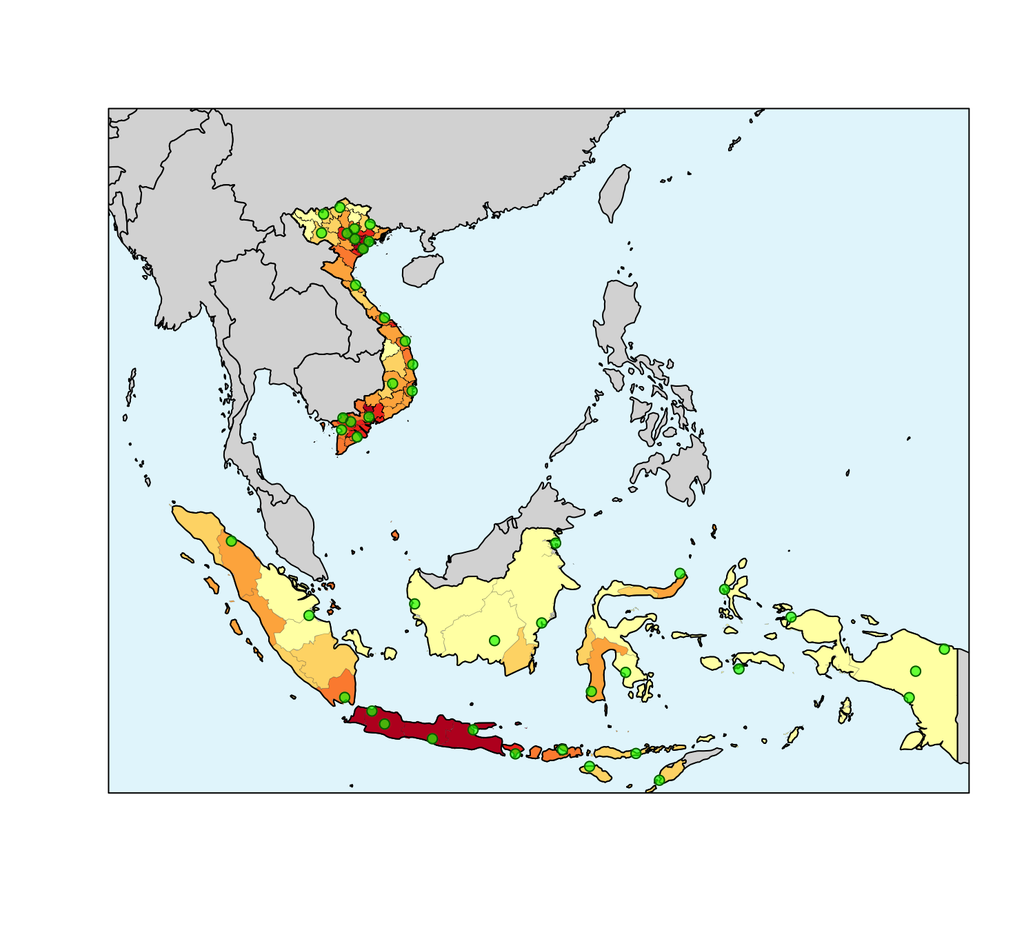

```r
lwd <- .1

sea %>%
  st_geometry() %>%
  plot(xlim = bb[c(1, 3)], ylim = bb[c(2, 4)], xaxs = "i", yaxs = "i")

rect(-180, -90, 180, 90, col = blue)

worldmap %>%
  st_geometry() %>%
  plot(xlim = bb[c(1, 3)], ylim = bb[c(2, 4)], col = grey, add = TRUE)

add_gadm(vnm)
add_gadm(st_simplify(idn, FALSE, .05))

worldmap %>%
  filter(ADMIN %in% c("Indonesia", "Vietnam")) %>%
  st_geometry() %>%
  plot(add = TRUE)

plot(vnm_sites, col = adjustcolor("green", .7), pch = 19, add = TRUE)
plot(idn_sites, col = adjustcolor("green", .7), pch = 19, add = TRUE)

plot(vnm_sites, col = "darkgreen", add = TRUE)
plot(idn_sites, col = "darkgreen", add = TRUE)

box(bty = "o")
```

The figure of the color scale:

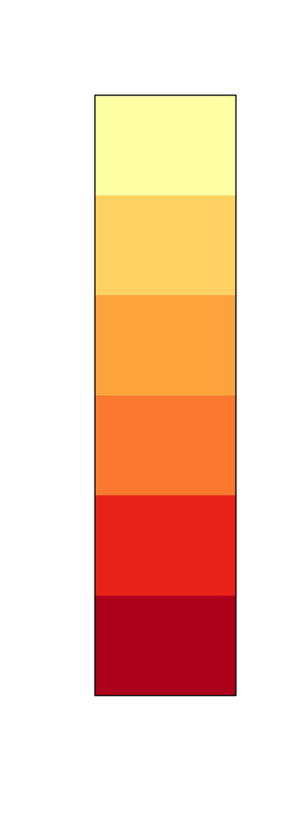

```r
image(t(matrix(length(prov):1)), col = prov, axes = FALSE)
box(bty = "o")
```

## A map for Vietnam only:

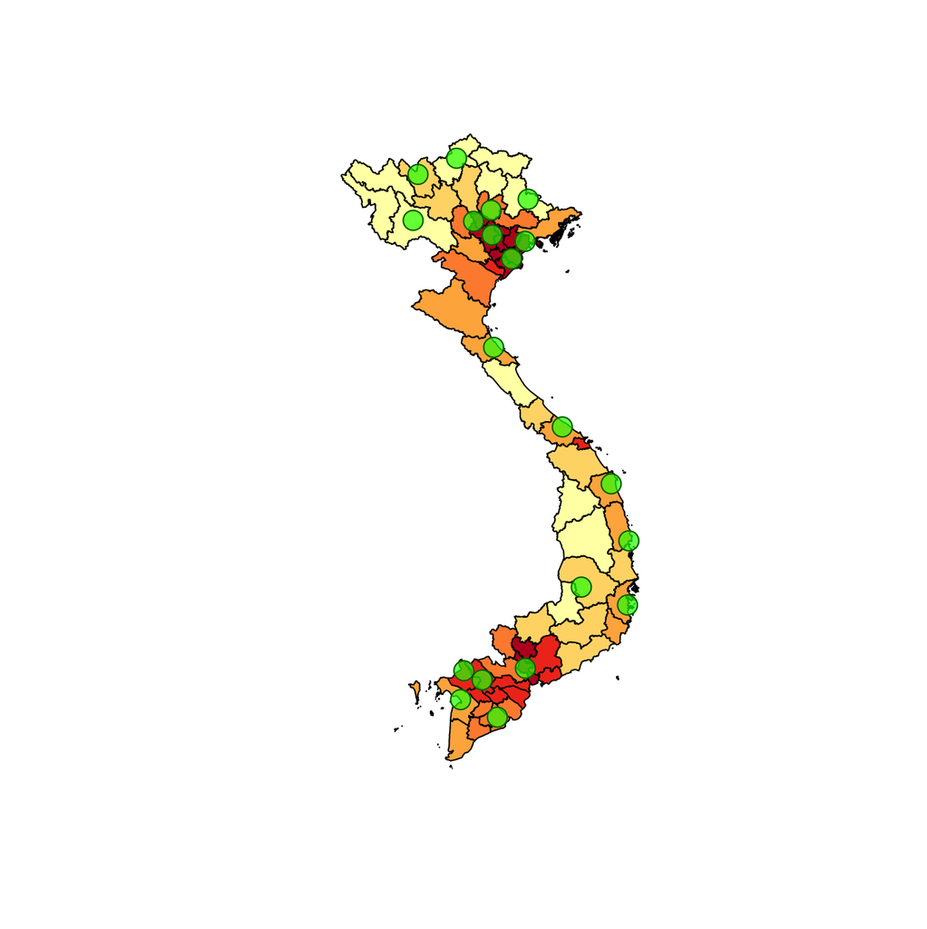

```r
cex_val <- 2

vnm %>%
  st_geometry() %>%
  plot(col = prov[discretize(vnm$density, quantile(vnm$density, seq(0, 1, le = nb_col + 1)))])

plot(vnm_sites, col = adjustcolor("green", .7), pch = 19, cex = cex_val, add = TRUE)
plot(vnm_sites, col = "darkgreen", cex = cex_val, add = TRUE)
```